# Expected Incremental Benefit Plot

## Introduction

The intention of this vignette is to show how to plot different styles of expected incremental benefit (EIB) plots using the BCEA package.

## Two interventions only

This is the simplest case, usually an alternative intervention ($i=1$) versus status-quo ($i=0$).

The plot is based on the incremental benefit as a function of the willingness to pay $k$.

$$IB(\theta) = k \Delta_e - \Delta_c$$

Using the set of $S$ posterior samples, the EIB is approximated by

$$\frac{1}{S} \sum_s^S IB(\theta_s)$$

where $\theta_s$ is the realised configuration of the parameters $\theta$ in correspondence of the $s$-th simulation.

#### R code

To calculate these in BCEA we use the `bcea()` function.

```r
data(Vaccine)

he <-
  bcea(eff, cost,
       ref = 2,
       interventions = treats,
       Kmax = 50000,
       plot = FALSE)
```

The default EIB plot gives a single diagonal line using base R.

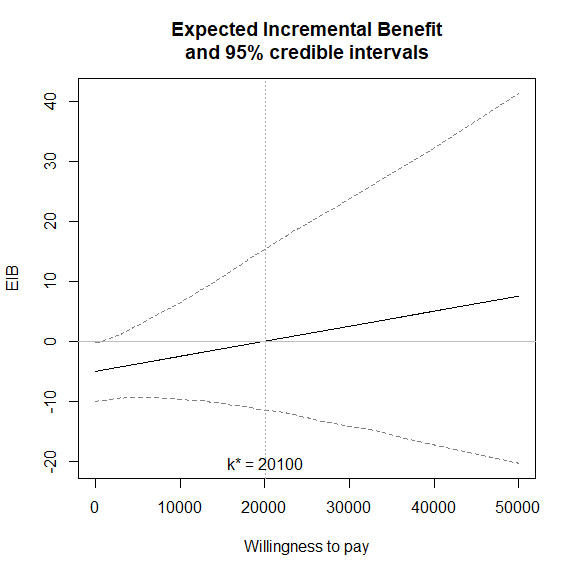

```r
eib.plot(he)
```

The vertical line represents the break-even value corresponding to $k^*$ indicating that above that threshold the alternative treatment is more cost-effective than the status-quo.

$$k^* = \min\{ k : \mbox{EIB} > 0 \}$$

This will be at the point the curve crosses the *x*-axis.

The plot defaults to base R plotting. Type of plot can be set explicitly using the `graph` argument.

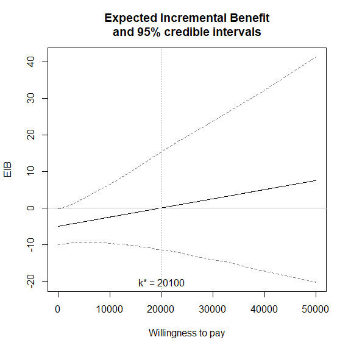

```r
eib.plot(he, graph = "base")
```

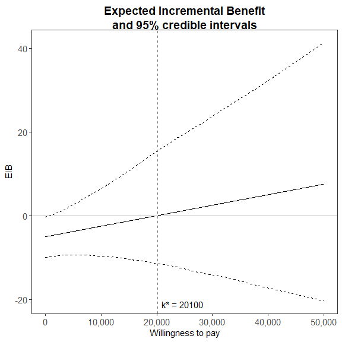

```r
eib.plot(he, graph = "ggplot2")
```

```r
# ceac.plot(he, graph = "plotly")
```

Other plotting arguments can be specified such as title, line colours and theme.

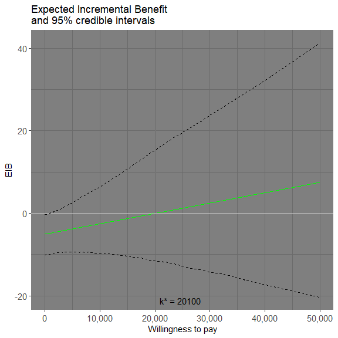

```r
eib.plot(he,
         graph = "ggplot2",
         main = "my title",
         line = list(color = "green"),
         theme = theme_dark())
```

Credible interval can also be plotted using the `plot.cri` logical argument.

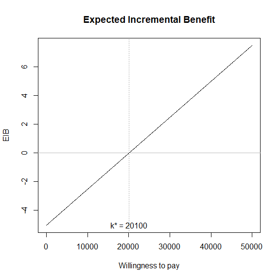

```r
eib.plot(he, plot.cri = FALSE)
```

## Multiple interventions

This situation is when there are more than two interventions to consider. Incremental values can be obtained either always against a fixed reference intervention, such as status quo, or for all comparisons simultaneously.

The curves are for pair-wise comparisons against a status-quo and the vertical lines and k* annotation is for simultaneous comparisons.

Without loss of generality, if we assume status quo intervention $i=0$, then we wish to calculate

$$\frac{1}{S} \sum_s^S IB(\theta^{i0}_s) \;\; \mbox{for each} \; i$$

The break-even points represent no preference between the two best interventions at $k$.

$$k^*_i = \min\{ k : \mbox{EIB}(\theta^i) > \mbox{EIB}(\theta^j) \}$$

Only the right-most of these will be where the curves cross the x-axis.

#### R code

This is the default plot for `eib.plot()` so we simply follow the same steps as above with the new data set.

```r
data(Smoking)

treats <- c("No intervention", "Self-help",
            "Individual counselling", "Group counselling")
he <- bcea(eff, cost, ref = 4, interventions = treats, Kmax = 500)

eib.plot(he)
```

[output not shown]

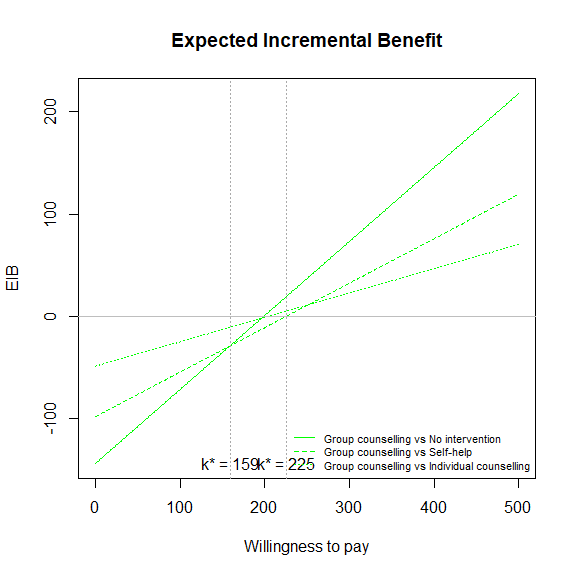

```r
eib.plot(he,
         graph = "base",
         main = "my title",
         line = list(color = "green"))
```

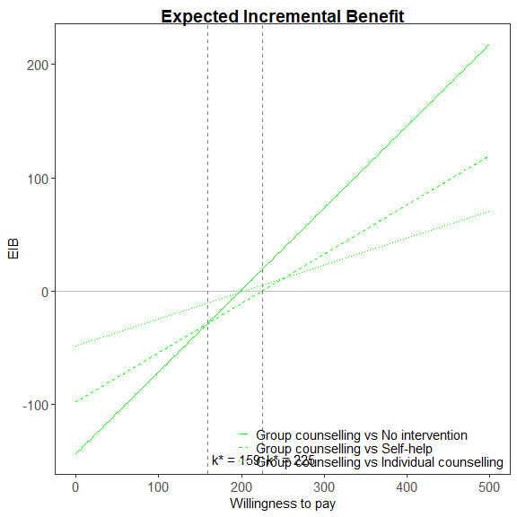

```r
eib.plot(he,
         graph = "ggplot2",
         main = "my title",
         line = list(color = "green"))
```

Credible interval can also be plotted as before. This isn’t recommended in this case since its hard to understand with so many lines.

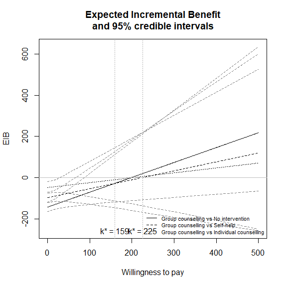

```r
eib.plot(he, plot.cri = TRUE)
```

##### Repositioning the legend.

For base R,

```r
eib.plot(he, pos = FALSE) # bottom right
```

[output not shown]

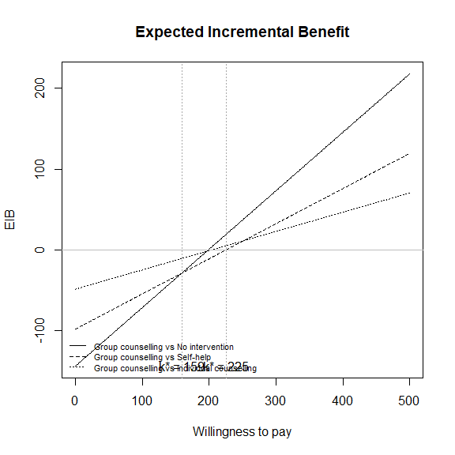

```r
eib.plot(he, pos = c(0, 0))
```

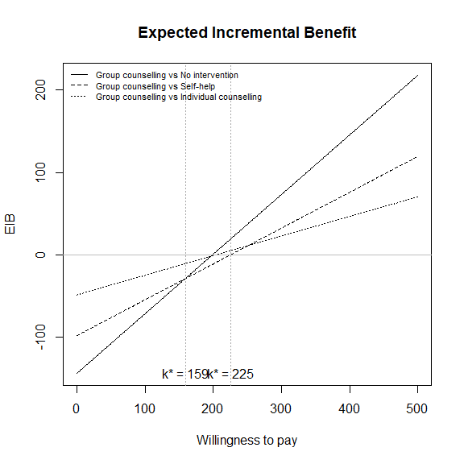

```r
eib.plot(he, pos = c(0, 1))
```

```r
eib.plot(he, pos = c(1, 0))
```

[output not shown]

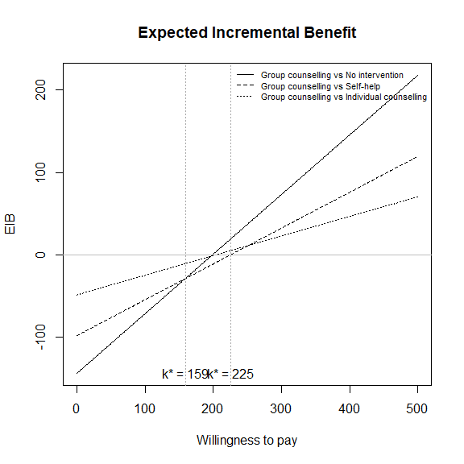

```r
eib.plot(he, pos = c(1, 1))
```

For `ggplot2`,

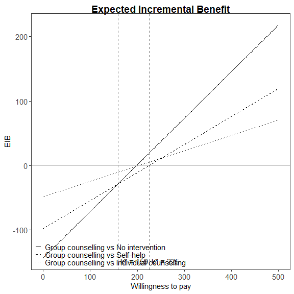

```r
##TODO:
eib.plot(he, graph = "ggplot2", pos = c(0, 0))
```

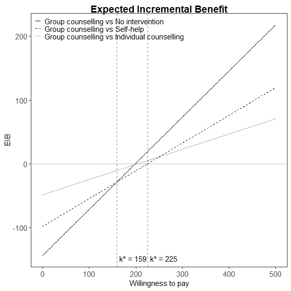

```r
eib.plot(he, graph = "ggplot2", pos = c(0, 1))
```

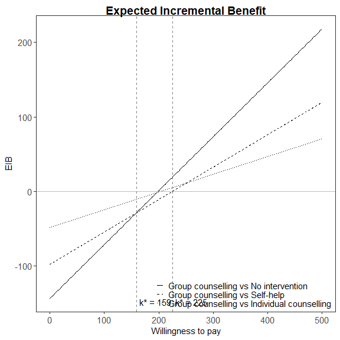

```r
eib.plot(he, graph = "ggplot2", pos = c(1, 0))
```

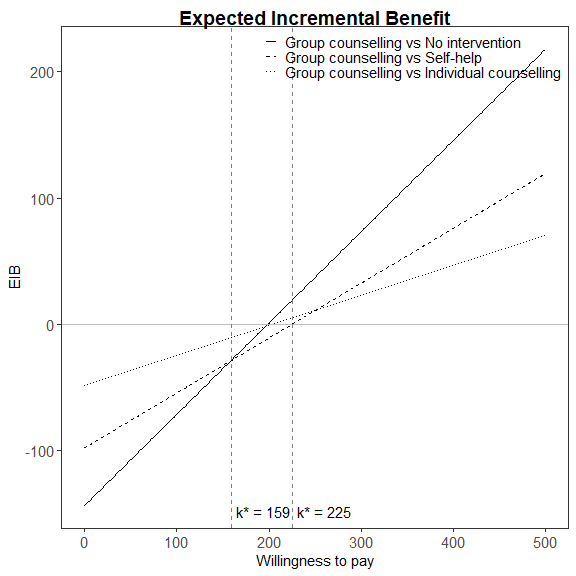

```r
eib.plot(he, graph = "ggplot2", pos = c(1, 1))
```

Define colour palette for different colour for each EIB line.

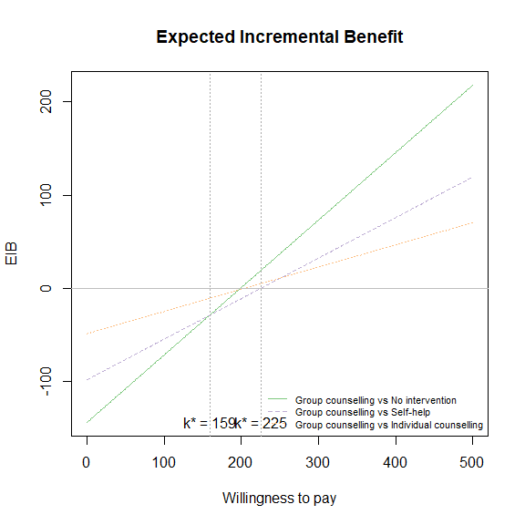

```r
mypalette <- RColorBrewer::brewer.pal(3, "Accent")

eib.plot(he,
         graph = "base",
         line = list(color = mypalette))
```

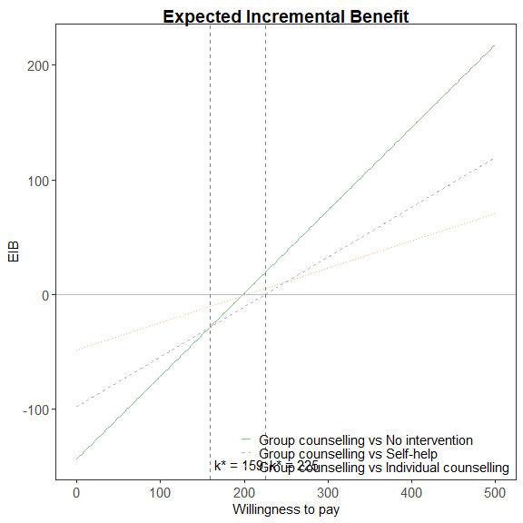

```r
eib.plot(he,
         graph = "ggplot2",
         line = list(color = mypalette))
```